# The Determinant of Loan Interest Rate

## Dataset Overview

The data set covers the time period 2005 to 2014, the first 9 years of the business. loan, including loan amount, borrower rate (or interest rate),current loan status, borrower income, and many others.It contains 113,937 observations of 81 variables. I chose to explore 11 variables in this dataset:Loan origination date, Loan original amount, Term, Loan Status, Borrower monthly income, Credit score, Debt to income ratio, Is borrower homeowner, Delinquencies in the last 7 years, EmploymentStatus.

## Investigation Overview

For this presentation, I focus on the determinants of interest rate and trying to find out what factor affects the borrower’s interest rate.

## Distribution of Interest Rate

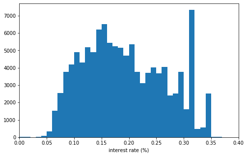

```python
# plotting the distribution of interest rate
bin_size=0.01
plt.figure(figsize=[8, 5])
bins = np.arange(0,df['BorrowerRate'].max()+bin_size,bin_size)
plt.hist(data=df,x='BorrowerRate',bins=bins);
# plt.title('Distribution of interest rate');
plt.xlabel('interest rate (%)')
plt.xlim([0.0,0.4]);
```

## Distribution of Loan Terms

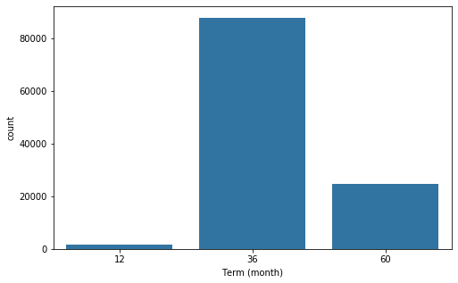

```python
# plotting term of loans
plt.figure(figsize=(8,5))
base_color = sns.color_palette()[0]
sns.countplot(data=df,x='Term',color=base_color);
plt.xlabel('Term (month)');
# plt.title('Distribution Loan Terms');
```

## Distribution of Loan Original Amount

The amount of loan in this dataset has mostly small loans. There are spikes at 4000, the minimum loan is set at $1000. Loan Original Amount in the dataset take on a large range, therefore I Plotted on a logarithmic scale.

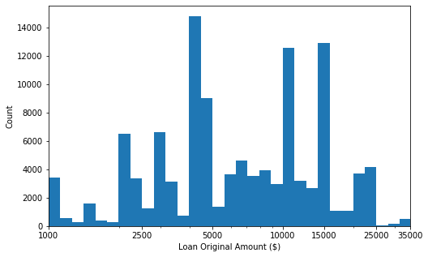

```python
# plotting LoanOriginalAmount with log transformation
log_binsize=0.05
plt.figure(figsize=[8, 5])
bins = 10 ** np.arange(2,np.log10(df['LoanOriginalAmount'].max())+log_binsize,log_binsize)

plt.hist(data=df,x='LoanOriginalAmount',bins=bins);
plt.xscale('log')
# plt.xticks=(['1000', '5000', '10000', '25000', '50000'], ['1k', '5k', '10k', '25k', '50k'])
ticks=[1000,2500, 5000, 10000, 15000,25000, 35000]
labels=['{}'.format(v) for v in ticks]

plt.xticks(ticks,labels)

plt.xlabel('Loan Original Amount ($)')
plt.ylabel('Count')
plt.xlim(1000, 35000);
```

## Distribution of Loan Status

Most borrowers are in "current" and "completed" status (around 83%); there is 17% of borrowers who didn't repay their loans on time

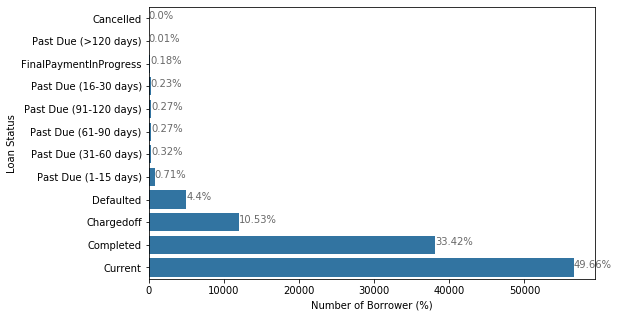

```python
# plotting the LoanStatus
plt.figure(figsize=[8, 5])
base_color = sns.color_palette()[0]
ax = sns.countplot(data=df,y='LoanStatus',color=base_color);
# add annotations
# create a list to collect the plt.patches data
totals = []

# find the values and append to list
for i in ax.patches:
    totals.append(i.get_width())

# set individual bar lables using above list
total = sum(totals)

# set individual bar lables using above list
for i in ax.patches:
    # get_width pulls left or right; get_y pushes up or down
    ax.text(i.get_width()+.3, i.get_y()+.38, \
            str(round((i.get_width()/total)*100, 2))+'%', fontsize=10,
color='dimgrey')

# invert for largest on top
ax.invert_yaxis()
plt.ylabel('Loan Status')
plt.xlabel('Number of Borrower (%)');
# plt.title('Distribution of LoanStatus');
```

## Distribution of Employment Status

It is not suprised that most of borrower are employed and having full time jobs.

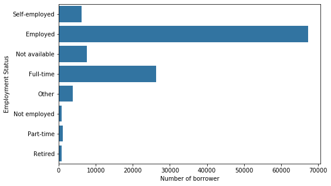

```python
# replace NA with Not available
df['EmploymentStatus'].fillna('Not available', inplace=True)
# exploring more about borrower
plt.figure(figsize=[8, 5])
base_color = sns.color_palette()[0]
sns.countplot(data=df,y='EmploymentStatus',color=base_color);
plt.xlabel('Number of borrower')
plt.ylabel('Employment Status');
```

## Distribution of Average Credit Score

The majority of borrowers have credit scores around 700. The minimum credit score is 420. Credit scores were not available for 569 borrowers, and 133 borrowers had credit scores in the 0 to 19 range. I removed these records from the dataset. I will take a closer look at credit scores later.

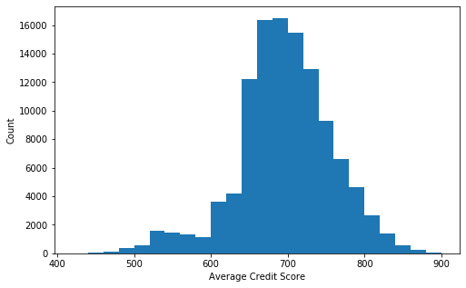

```python
# re-plot the distribution of averge Credit Score
plt.figure(figsize=[8, 5])
bins = np.arange(420, max(df['average_CreditScore'])+20, 20)
plt.hist(data=df,x='average_CreditScore',bins=bins);
plt.xlabel('Average Credit Score')
plt.ylabel('Count');
```

## Distribution of Monthly Income

The maximum reported monthly income was over 1 million, and there were several other outliers, but the majority of the data was between 0 and 10000 so the graph is zoomed in on this part. The graph is skewed to the right as is expected of income distributions. There are small spikes at multiples of 10000, which are commonly reported incomes. Some borrowers are unemployed and reported monthly incomes of 0.

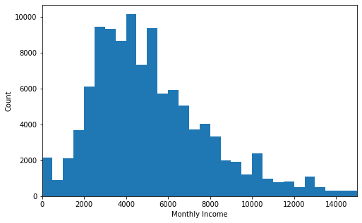

```python
# plot Monthly Income
plt.figure(figsize=[8, 5])
bins = np.arange(min(df['StatedMonthlyIncome']), max(df['StatedMonthlyIncome'])+500, 500)
plt.hist(data=df,x='StatedMonthlyIncome',bins=bins);
plt.xlabel('Monthly Income')
plt.ylabel('Count');
plt.xlim(0,15000);
```

## Distribution of DebtTo Income Ratio

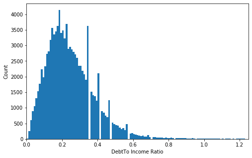

```python
# investigating further on an even smaller bin size
bin_size=0.01
plt.figure(figsize=[8, 5])
bins = np.arange(df['DebtToIncomeRatio'].min(),df['DebtToIncomeRatio'].max()+bin_size,bin_size)
plt.hist(data=df,x='DebtToIncomeRatio',bins=bins);
plt.xlabel('DebtTo Income Ratio')
plt.ylabel('Count');
plt.xlim(0,1.25);
```

## Interest Rate vs. Average Credit Score

There is a moderate negative correlation here, people with higher credit scores have a lower loan interest rate, or people who want to borrow at a lower interest rate must have a higher credit score.

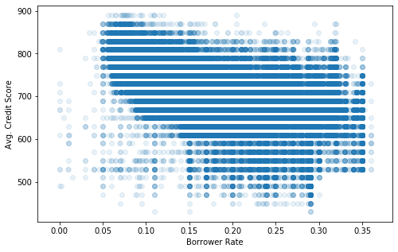

```python
# scatter plot of interest rate vs. average credit score
plt.figure(figsize = [8, 5])
plt.scatter(data = df, y = 'average_CreditScore', x = 'BorrowerRate', alpha = 1/10)
plt.ylabel('Avg. Credit Score')
plt.xlabel('Borrower Rate');
```

## Interest Rate and Delinquencies Last 7 Years

The number of delinquencies does not have a strong correlation with the interest rate as I thought. It seems that there is still a positive relationship between them. Let's see the relationship between Credit Score and delinquencies later. Maybe the relationship will be clearer with a scatterplot of delinquencies and credit score.

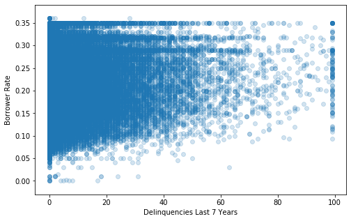

```python
# scatter plot of interest rate vs. Number of Delinquencies in last 7 years
plt.figure(figsize = [8, 5])
plt.scatter(data = df, y = 'BorrowerRate', x = 'DelinquenciesLast7Years', alpha = 1/5)
plt.xlabel('Delinquencies Last 7 Years')
plt.ylabel('Borrower Rate');
```

## Credit Score and Delinquencies Last 7 Years

It seems that there’s a negative correlation which is still not as strong as I would expect it to be. I find it abnormal that the people can get a credit score of more than 500 with more than 80 delinquencies in the past 7 years.

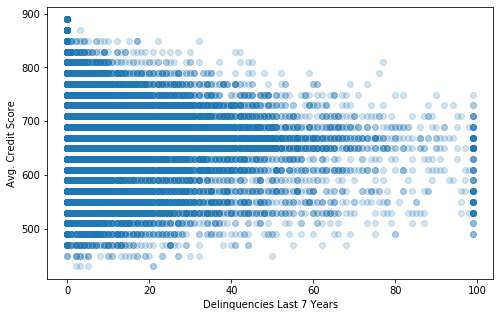

```python
# scatter plot of interest rate vs. Number of Delinquencies in last 7 years
plt.figure(figsize = [8, 5])
plt.scatter(data = df, y = 'average_CreditScore', x = 'DelinquenciesLast7Years', alpha = 1/5)
plt.xlabel('Delinquencies Last 7 Years')
plt.ylabel('Avg. Credit Score');
```

## Credit Score and Loan Original Amount

It’s clear that there’s a positive correlation which is not as strong as I would expect it to be. People with higher credit scores tend to borrow more, or people who want to borrow more must have a higher credit score.

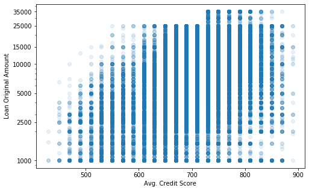

```python
# scatter plot of interest rate vs. average credit score

plt.figure(figsize = [8, 5])
plt.scatter(data = df, y = 'LoanOriginalAmount', x = 'average_CreditScore', alpha = 1/10)
plt.yscale('log')
ticks=[1000,2500, 5000, 10000, 15000,25000, 35000]
labels=['{}'.format(v) for v in ticks]

plt.yticks(ticks,labels)
plt.ylabel('Loan Original Amount')
plt.xlabel('Avg. Credit Score');
```

## Interest rate and Monthly Income

In general, borrowers with higher salaries tend to get a lower loan interest rate. It seems there are some low outliers below 0.05 interest rates.

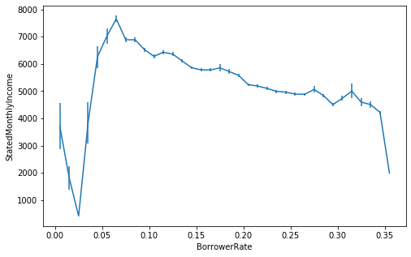

```python
# plot line chart between average monthly income and interest rate
# set bin edges, compute centers
bin_size = 0.01
plt.figure(figsize=[8, 5])
xbin_edges = np.arange(0, df['BorrowerRate'].max()+bin_size, bin_size)
xbin_centers = (xbin_edges + bin_size/2)[:-1]

# compute statistics in each bin
data_xbins = pd.cut(df['BorrowerRate'], xbin_edges, right = False, include_lowest = True)
y_means = df['StatedMonthlyIncome'].groupby(data_xbins).mean()
y_sems = df['StatedMonthlyIncome'].groupby(data_xbins).sem()

# plot the summarized data
plt.errorbar(x = xbin_centers, y = y_means, yerr = y_sems)
plt.xlabel('BorrowerRate')
plt.ylabel('StatedMonthlyIncome');
```

## Interest Rate and Credit Score by delinquency Status

As we know, delinquency is correlated with credit scores and interest rates. We have a more clear result, people who are delinquent tend to get higher interest rates than people with good records and have lower credit scores than people with good records.

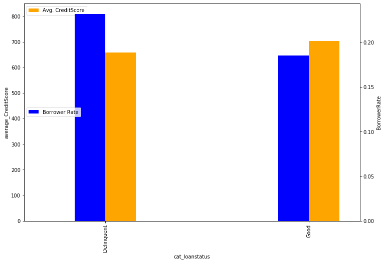

```python
# reference: https://stackoverflow.com/questions/24183101/pandas-bar-plot-with-two-bars-and-two-y-axis
# Create matplotlib figure
fig = plt.figure(figsize=(8,5))
# Create matplotlib axes
ax = fig.add_subplot(111)
# Create another axes that shares the same x-axis as ax.
ax2 = ax.twinx()

width = 0.15

average_CreditScore = pivot_employstatus.plot(x='cat_loanstatus', y='average_CreditScore', kind='bar', color = 'orange',
                  width=width, ax=ax, position = 0, figsize=(12,8), label = 'Avg. CreditScore')
BorrowerRate = pivot_employstatus.plot(x='cat_loanstatus', y='BorrowerRate', kind='bar', color = 'blue',
                  width=width, ax=ax2, position = 1, figsize=(12,8), label = 'Borrower Rate')


ax.set_ylabel('average_CreditScore')
average_CreditScore.legend(loc='upper left')
ax.set(adjustable='box', ylim=(0,850))
ax2.set_ylabel('BorrowerRate')
ax2.legend(loc='center left')
ax.set_xlabel('cat_loanstatus');
# plt.title('Interest Rate and Credit Score by delinquency Status');
```

## Debt To Income Ratio and Credit Score for Interest Rate

Debt to income ratio and Average credit score explains the variation in interest rate.

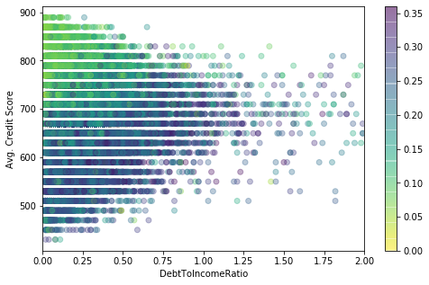

```python
# debt to income ratio and credit score by interest rate
plt.figure(figsize=[8, 5])
plt.scatter(data = df, x = 'DebtToIncomeRatio', y = 'average_CreditScore', c = 'BorrowerRate',cmap='viridis_r',alpha=1/3);
plt.xlabel('DebtToIncomeRatio')
plt.xlim(0,2);
plt.ylabel('Avg. Credit Score');
plt.colorbar();
```

## Interest Rate and Employment Status by delinquency Status

Employment status and cat loan status explain the variation in interest rate.

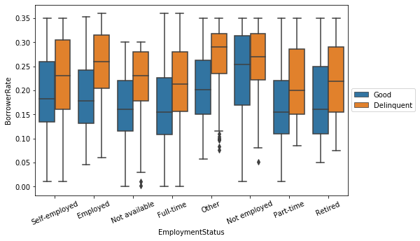

```python
plt.figure(figsize=[8, 5])
sns.boxplot(data=df,x='EmploymentStatus',y='BorrowerRate',hue='cat_loanstatus',dodge=0.3);
plt.xticks(rotation=23);
plt.legend(loc = 6, bbox_to_anchor = (1.0, 0.5)) ;
```

## Debt To Income Ratio and Employment Status by delinquency Status

A dodged point plot for loans shows the clear influence of employment status and loan status on the DTI ratio. Delinquents have a higher DTI ratio than good borrowers, except borrowers with part-time jobs.

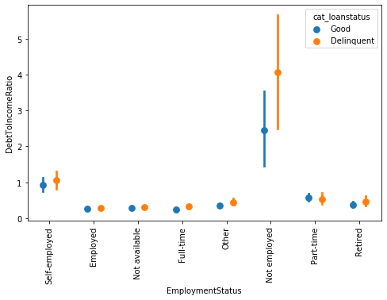

```python
plt.figure(figsize=[8, 5])
ax = sns.pointplot(data=df,x='EmploymentStatus',y='DebtToIncomeRatio',hue='cat_loanstatus',dodge=0.3,linestyles='');
plt.xticks(rotation=90);
```

# Conclusion